# Homework 1

Author

Affiliation

Nicholas Adu Gyamfi

Old Dominion University

Understanding labor market outcomes is crucial for gaining insights into economic dynamics and societal structures. The 1976 Panel Study of Income Dynamics (PSID) serves as a valuable dataset for such an analysis, capturing a comprehensive snapshot of American households at a particular time. These data document labor market outcomes for women with additional information about their partners’ labor market outcomes. Investigating the factors influencing female wages provides a nuanced perspective on gender dynamics, labor market trends, and the distribution of economic opportunities within households.

Analyzing wages between spouses allows us to explore questions related to gender equity, workforce participation, and the impact of educational attainment. Educational levels, for instance, may influence both the individual’s and the spouse’s earning potential, shedding light on the interplay between education and labor market outcomes within a family unit. Additionally, considering an additional child in the household introduces a complex dynamic, as it may affect labor force participation, career choices, and subsequently, wages.

Regression analysis emerges as a powerful tool for examining these relationships, enabling the quantification of the impact of various factors on wages. By controlling for relevant characteristics, such as education and the labor market status of partners, regression models can provide a clearer understanding of the specific influences shaping labor market outcomes for women. This exploration not only contributes to our comprehension of societal structures but also provides empirical insights essential for crafting informed policies aimed at fostering equality and economic well-being.

In this homework, you will explore [PSID data](https://vincentarelbundock.github.io/Rdatasets/csv/AER/PSID1976.csv) ([documentation](https://vincentarelbundock.github.io/Rdatasets/doc/AER/PSID1976.html)) and generate empirical insights about the labor market for women in 1976.

## Question 1

Use the data linked above to answer the following.

1. Read the data into an object called `psid`. (**0 Points**)

```r
# Load data
psid <- read.csv("https://vincentarelbundock.github.io/Rdatasets/csv/AER/PSID1976.csv")
```

2. Subset the `data.frame` to include only the following columns: (**0 Points**)
- `wage`: wife’s hourly wage in 1975 dollars.
- `hours`: wife’s hours worked in 1975.
- `education`: wife’s education measured in number of years.
- `age`: wife’s age.
- `youngkids`: number of children under six years old.
- `oldkids`: number of children between six and eighteen.
- `hwage`: husband’s hourly wage in 1975 dollars.
- `hhours`: husband’s hours worked in 1975.
- `heducation`: husband’s education measured in number of years.
- `hage`: husband’s age.
- `unemp`: unemployment rate in county of residence, in percentage points.
- `city`: whether the couple lives in a large city.

```r
# Subset data for specified columns
keep_columns <- c("wage","hours","education","age","youngkids","oldkids","hwage","hhours","heducation","hage","unemp","city")
psid <- psid[,keep_columns]
```

3. Convert `city` into a binary variable equal to one if the couple lived in a large city and zero otherwise. (**0 Points**)

```r
# Convert variable into binary
psid$city <- ifelse((psid$city == "yes"), 1, 0)
```

4. Create an `employed` variable equal to 1 if the woman worked in 1975. (**0 Points**)

```r
# Loop statement
psid$employed <- ifelse((psid$hours > 0), 1, 0)
```

5. Using functions from the `modelsummary` package, create a summary statistics table. Then, using this table, discuss some empirical facts.[^1] (**2 Points**)

```r
# Summary Statistics
library(modelsummary)

datasummary_skim(psid, fmt = "%.3f")
```

|  | Unique | Missing Pct. | Mean | SD | Min | Median | Max |  |
| --- | --- | --- | --- | --- | --- | --- | --- | --- |
| wage | 374 | 0 | 2.375 | 3.242 | 0.000 | 1.625 | 25.000 |  |
| hours | 306 | 0 | 740.576 | 871.314 | 0.000 | 288.000 | 4950.000 |  |
| education | 13 | 0 | 12.287 | 2.280 | 5.000 | 12.000 | 17.000 |  |
| age | 31 | 0 | 42.538 | 8.073 | 30.000 | 43.000 | 60.000 |  |
| youngkids | 4 | 0 | 0.238 | 0.524 | 0.000 | 0.000 | 3.000 |  |
| oldkids | 9 | 0 | 1.353 | 1.320 | 0.000 | 1.000 | 8.000 |  |
| hwage | 697 | 0 | 7.482 | 4.231 | 0.412 | 6.976 | 40.509 |  |
| hhours | 422 | 0 | 2267.271 | 595.567 | 175.000 | 2164.000 | 5010.000 |  |
| heducation | 15 | 0 | 12.491 | 3.021 | 3.000 | 12.000 | 17.000 |  |
| hage | 31 | 0 | 45.121 | 8.059 | 30.000 | 46.000 | 60.000 |  |
| unemp | 7 | 0 | 8.624 | 3.115 | 3.000 | 7.500 | 14.000 |  |
| city | 2 | 0 | 0.643 | 0.480 | 0.000 | 1.000 | 1.000 |  |
| employed | 2 | 0 | 0.568 | 0.496 | 0.000 | 1.000 | 1.000 |  |

The average age for wives is 42.5years, whilst the average age for husbands is 45.1years, thus average age gap within couples is 2.6years. The average wage for wives is 2.4, whilst the average wage for husbands is 7.5, the average wage gap gap is 5.1. Of the number of females sampled, 56.8% were employed in 1975. There was an average of 0.2 youngkids and 1.4 older kids in total. Thus we have an average of 1.6 approximately 2 children of the women sampled. Wife’s average hours of work in 1975 was 740.6 whilst husbands hours of work was 2,267.271, showing a gap of 1,526.671. on average 64% of the sampled respondents lived in the city. Wife’s education in years was 12.287years and husbands education in years was 12.491 years.

## Question 2

In this question, you will explore some of the variables in the data.

1. Use the `density()` function to plot the wage distribution for husbands of employed and unemployed women in 1975. What do you learn from this figure? (**2 Points**)

```r
##### Alex - two plots (employed = 1, employed = 0) on the same graph

hwage_e <- density(psid$hwage[psid$employed == 1])
hwage_u <- density(psid$hwage[psid$employed == 0])

plot(hwage_e, main = "Wage distribution of husbands of Employed and Unemployed Women 1975", xlab = "Wage", ylab = "Density", col = "tomato", lwd = 2, cex.main = 0.8)
lines(hwage_u, col = "blue", lwd = 2, cex.main = 0.8)
legend("topright", legend = c("Hus Employed", "Hus Unemployed"), col = c("blue", "tomato"), pch = c(16, 17), lty = c(1, 2), bty = "n", cex = 0.8)
```

**Plot**

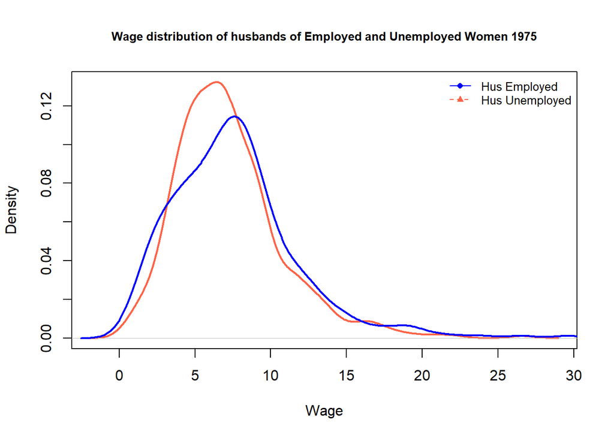

2. Tabulate the *total* number of children for the women sampled. What do you learn from this figure? (**1 Point**)

```r
# Your code here...

child_totals <- table(psid$youngkids, psid$oldkids)
child_table <- addmargins(child_totals)
print(child_table)
```

**Output**

```
        0   1   2   3   4   5   6   7   8 Sum
  0   229 144 121  75  26   9   0   1   1 606
  1    17  35  36  24   3   3   0   0   0 118
  2    11   5   5   3   1   0   1   0   0  26
  3     1   1   0   1   0   0   0   0   0   3
  Sum 258 185 162 103  30  12   1   1   1 753
```

3. Calculate the average number of young and old children (separately) by age. Plot the relationship between children and age. What do you learn from this figure? (**2 Points**)

```r
### Alex - Add xlim and ylim to show the plots

# Average number of young children by age:
young_c <- aggregate(list(avg_n_young = psid$youngkids,avg_n_old = psid$oldkids),
          list(Wife_Age = psid$age),
          mean)

# Relationship between wife's age and average number of young children
plot(young_c$Wife_Age, young_c$avg_n_young,
     main = "Relationship Between Wife's Age and Average Number of young and old children",
     xlab = "Wife's Age", ylab = "Average No. of young/old children", type = "l", cex.main = 0.85, col = "tomato",
     xlim = range(young_c$Wife_Age),
     ylim = range(young_c$avg_n_old))

# Relationship between wife's age and average number of old children
lines(young_c$Wife_Age, young_c$avg_n_old, col = "blue")
legend("topright", legend = c("Old Children", "Young children"), col = c("blue", "tomato"), pch = c(16, 17), lty = c(1, 2), bty = "n", cex = 0.8)
```

**Plot**

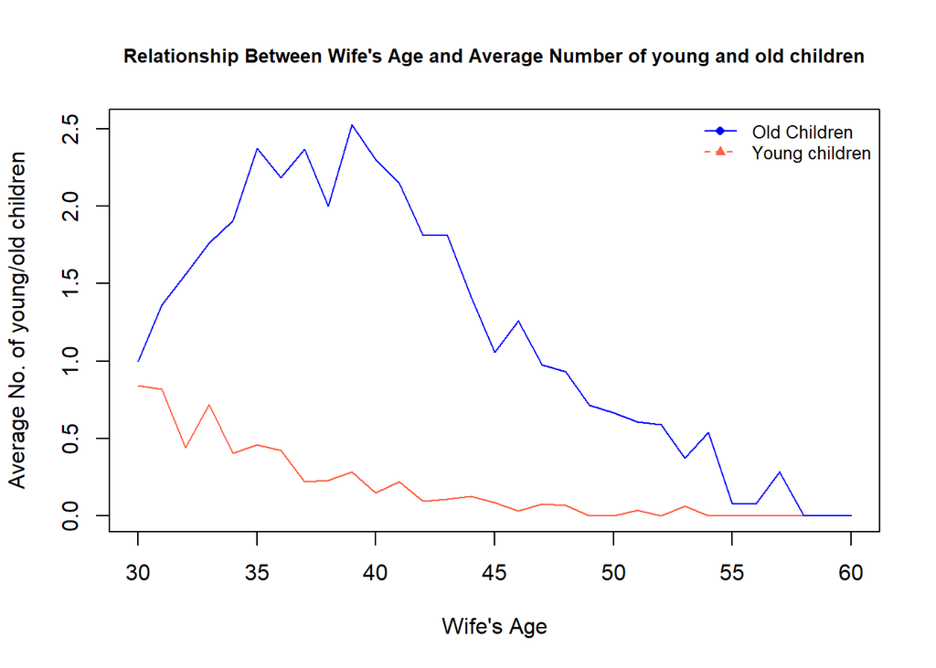

The table above depicts the relationship between wife’s age and average number of young and old children. At age 30 average number of young and old children seem to be the same. Interestingly as the years increases average number of old children increases to a peak of 2.5 at about age 40 and thereafter declines steadily towards age 60. Average number of young children however declines steadily after age 30 until age 60. This shows that the fertile age of most women peaks at age 40, not only this it shows that most women prefer to give birth at age 30 as the number of young children decreases after age 30.

4. Generate a scatter plot between a woman’s wages and her husband’s wages. Be sure to include axis labels, etc. Add a diagonal line that denotes y = x. What are some things you can learn from this plot? (**1 Point**)

```r
library(scales)

## Scatter Plot Between Woman's Wages and Husband's Wages
## Col = alpha("color", opacity_level)
plot(psid$hwage, psid$wage,
     main = "Relationship between wife's wages and husband's wages",
     xlab = "Husband's wages", ylab = "Wife's wages", type = "p", col = alpha("tomato", 0.85), cex.main = 1)
abline(a = 0, b = 1, col = alpha("blue", 2), lty = 2)
legend("topright", legend = c("abline", "wages"), col = c("blue", "tomato"), pch = c(16, 17), lty = c(2, 20), bty = "n", cex = 0.8)
```

**Plot**

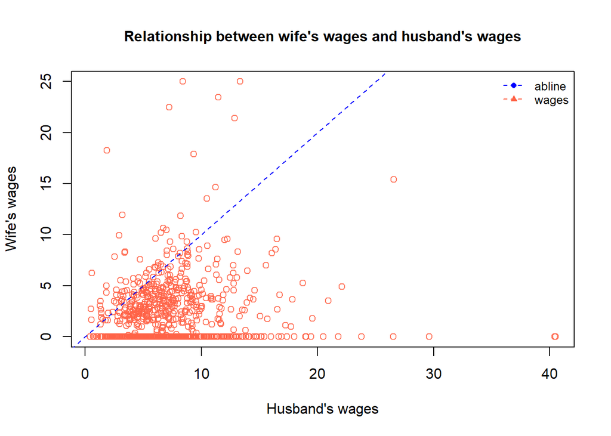

## Question 3

For this question, you will estimate two regressions. First, you will estimate a model to explain a woman’s wages using characteristics pertaining to her and/or her husband. Second, estimate the same model using only the subset of women with non-zero wages. At the end, use functions from the `modelsummary` package to present the results.

1. Estimate a model where a woman’s wages is a function of factors pertaining to her and/or her husband. You may use any variable, or combination of variables, except for the variable that indicates whether a woman is employed. For each variable you choose to include in the model, provide a short rationale for why you believe it belongs, and the effect you anticipate it having on wages. (**2 Points**)

```r
# Regression of noted variables on wife's wage except employed:
#r1 <- lm(wage ~ education + age + youngkids + oldkids + city + hours + hwage + hhours + heducation + hage + unemp, data = psid)
r1 <- lm(wage ~ education + age + youngkids + city, data = psid)
summary(r1)
```

**Output**

```
Call:
lm(formula = wage ~ education + age + youngkids + city, data = psid)

Residuals:
    Min      1Q  Median      3Q     Max
-5.0300 -2.1074 -0.4366  1.2884 23.4273

Coefficients:
            Estimate Std. Error t value Pr(>|t|)
(Intercept) -1.75448    0.94175  -1.863   0.0629 .
education    0.46587    0.04965   9.384  < 2e-16 ***
age         -0.03213    0.01532  -2.097   0.0363 *
youngkids   -1.19220    0.23448  -5.084 4.66e-07 ***
city         0.08544    0.23501   0.364   0.7163
---
Signif. codes:  0 '***' 0.001 '**' 0.01 '*' 0.05 '.' 0.1 ' ' 1

Residual standard error: 3.029 on 748 degrees of freedom
Multiple R-squared:  0.1316,    Adjusted R-squared:  0.127
F-statistic: 28.34 on 4 and 748 DF,  p-value: < 2.2e-16
```

1. Wife’s Education: Inclusion of education is based on the assumption that it is a factor that influences wages. Employers often use education as a signal of a person’s ability, and suitability for certain positions as such education tends to have positive effect on wages. I anticipate education will have positive effect on wife’s wages.
2. Wife’s Age: Different age groups may have distinct employment options. Thus, younger women might be more likely to seek employment after completing education, while older women might have varying employment patterns influenced by family responsibilities or retirement. I anticipate wife’s age to have a negative effect on wages.
3. Wife’s young children: The age of young children in the household can be a factor in determining how much time and effort a woman can devote to her career. Balancing work and family responsibilities is a common challenge. The age of young children in the household can be a factor in determining how much time and effort a woman can devote to her career. I anticipate wife’s with young children negatively impacts their wage potential.
4. Wife lives in City: The geographic location of the wife may be associated with different job opportunities, industries, and cost of living, which can influence wage levels. I anticipate that living in the city will positively impact their wage potential.
2. Re-estimate the model using only the subset of employed women. (**1 Point**)

```r
# Your code here...
r2 <- lm(wage ~ education + age + youngkids + city, data = psid[psid$employed == 1,])
options(scipen = 999)
summary(r2)
```

**Output**

```
Call:
lm(formula = wage ~ education + age + youngkids + city, data = psid[psid$employed ==
    1, ])

Residuals:
    Min      1Q  Median      3Q     Max
-5.9270 -1.6370 -0.5046  0.8795 21.0804

Coefficients:
            Estimate Std. Error t value         Pr(>|t|)
(Intercept) -2.98553    1.23676  -2.414           0.0162 *
education    0.48384    0.06740   7.179 0.00000000000318 ***
age          0.01816    0.02088   0.870           0.3849
youngkids    0.01772    0.41175   0.043           0.9657
city         0.42768    0.31973   1.338           0.1817
---
Signif. codes:  0 '***' 0.001 '**' 0.01 '*' 0.05 '.' 0.1 ' ' 1

Residual standard error: 3.115 on 423 degrees of freedom
Multiple R-squared:  0.123, Adjusted R-squared:  0.1147
F-statistic: 14.83 on 4 and 423 DF,  p-value: 0.00000000002384
```

3. Display the coefficients from both estimations in a single table. (**1 Point**)

```r
# Your code here...
regz <- list(`All Wife's` = r1,
             `Employed Wife's` = r2)

coefz <- c("education" = "Wife's Education",
           "age" = "Wife's age",
           "youngkids" = "Wife with young kids",
           "city" = "Wife live in city",
           "(Intercept)" = "Constant")

gofz <- c("nobs", "r.squared")

modelsummary(regz,
             title = "Effect of variables on Wife's wages",
             estimate = "{estimate}{stars}",
             coef_map = coefz,
             gof_map = gofz)
```

Effect of variables on Wife's wages

|  | All Wife's | Employed Wife's |
| --- | --- | --- |
| Wife's Education | 0.466*** | 0.484*** |
|  | (0.050) | (0.067) |
| Wife's age | −0.032* | 0.018 |
|  | (0.015) | (0.021) |
| Wife with young kids | −1.192*** | 0.018 |
|  | (0.234) | (0.412) |
| Wife live in city | 0.085 | 0.428 |
|  | (0.235) | (0.320) |
| Constant | −1.754+ | −2.986* |
|  | (0.942) | (1.237) |
| Num.Obs. | 753 | 428 |
| R2 | 0.132 | 0.123 |

4. Interpret the coefficients in the regressions. (**2 Points**)
1. Education: For each one-unit increase in education, the wife’s wages are estimated to increase by approximately 0.466 units, holding other variables constant. This coefficient is statistically significant.
2. Age: For each additional year of age, the wife’s wages are estimated to decrease by approximately 0.032 units. This effect is statistically significant.
3. Wife’s with young kids: A one additional young kid is associated with a wage decrease of approximately 1.192 units, holding other variables constant. This effect is statistically significant.
4. Wife’s live in City: Living in the city is associated with an increase of approximately 0.085 for each additional year of wife’s wages, but this effect is statistically insignificant.
5. Education: For the group of employed women only, each unit increase in education, the expected wage is estimated to increase by approximately 0.484 units. This effect is statistically significant.
6. Age: When considering employed women only, each additional year of age, the wife’s wages are estimated to increase by approximately 0.018 units. This effect is statistically insignificant.
7. Young Kids: For employed women only, an additional young kid is associated with an increase of 0.018 units in expected wage, but the effect is statistically insignificant.
8. City: For employed women only, living in the city is associated with an increase in expected wage by approximately 0.428 units, but the effect is statistically insignificant.
5. Do any of the coefficients change between regressions? Why or why not? Which regression do you prefer, and why? (**1 Point**) Coefficients for “Wife’s age”, “young kids”, “city” changed substantially between regressions. However coefficient for education did not change as much. The change in coefficient may be due to the effect of a smaller number of observations (428) when considering only employed wife’s as against (753) for the total dataset. This change may also be due to omitted variable bias.

I prefer the first regression that includes all wives against that for only employed wives. This is because it gives a bigger picture of regression outcomes as against the employed wife’s only regression that seems to omit relevant information helpful to interpret the regression.

## Question 4

The exercise in this question will be very similar to the last one, except the dependent variable will be binary.

1. Estimate a model that explains female employment status. Again, you may choose which variables you would like to use in the model, but you may not use the woman’s wages as an explanatory variable. For each variable you choose to include in the model, provide a short rationale for why you believe it belongs, and the effect you anticipate it having on employment. (**1 Point**)

```r
## Use Linear Probability Model(LMP) or Logistic Regression Model
r3 <- lm(employed ~ education + age + youngkids + city, data = psid)
summary(r3)
```

**Output**

```
Call:
lm(formula = employed ~ education + age + youngkids + city, data = psid)

Residuals:
    Min      1Q  Median      3Q     Max
-0.9054 -0.4881  0.2150  0.3902  0.9798

Coefficients:
             Estimate Std. Error t value             Pr(>|t|)
(Intercept)  0.617594   0.144732   4.267        0.00002234120 ***
education    0.044465   0.007630   5.828        0.00000000835 ***
age         -0.011774   0.002354  -5.002        0.00000070921 ***
youngkids   -0.303316   0.036036  -8.417 < 0.0000000000000002 ***
city        -0.035121   0.036117  -0.972                0.331
---
Signif. codes:  0 '***' 0.001 '**' 0.01 '*' 0.05 '.' 0.1 ' ' 1

Residual standard error: 0.4655 on 748 degrees of freedom
Multiple R-squared:  0.1225,    Adjusted R-squared:  0.1178
F-statistic: 26.11 on 4 and 748 DF,  p-value: < 0.00000000000000022
```

1. Education: Education can influence income levels and the availability of job opportunities. More educated individuals have access to a wider range of employment options.
2. Age of wife: As individuals age, they may accumulate work experience and develop expertise in their field. This could impact their likelihood of being employed.
3. Wife’s with young kids: Wives with young children may face increased childcare responsibilities, which can impact their decision to participate in the workforce.
4. Wife lives in city: Urban areas often offer a greater number and variety of employment opportunities compared to rural areas. Including this variable captures the potential impact of living in an urban setting on the likelihood of employment.
2. Display the coefficients in a table. (**1 Point**)

```r
# Your code here...
regz <- list(`Reg: Wife's Employment Status` = r3)

coefz <- c("education" = "Wife's Education",
           "age" = "Wife's age",
           "youngkids" = "Wife with young kids",
           "city" = "Wife live in city",
           "(Intercept)" = "Constant")

gofz <- c("nobs", "r.squared")

modelsummary(regz,
             title = "Effect of Variables on Wife's Employment Status",
             estimate = "{estimate}{stars}",
             coef_map = coefz,
             gof_map = gofz)
```

Effect of Variables on Wife's Employment Status

|  | Reg: Wife's Employment Status |
| --- | --- |
| Wife's Education | 0.044*** |
|  | (0.008) |
| Wife's age | −0.012*** |
|  | (0.002) |
| Wife with young kids | −0.303*** |
|  | (0.036) |
| Wife live in city | −0.035 |
|  | (0.036) |
| Constant | 0.618*** |
|  | (0.145) |
| Num.Obs. | 753 |
| R2 | 0.123 |

3. Interpret each coefficient in the regression. (**2 Points**)
1. Wife’s Educ: A one-unit increase in wife’s education is associated with a 4.4% increase in the probability of wife being employed. This coefficient is statistically significant.
2. Wife’s age: Each additional year of wife’s age is associated with a 1.2% decrease in the probability of wife being employed. This coefficient is statistically significant.
3. Wife with young kids: An additional young kid is associated with 30.3% decrease in the probability of wife being employed. This coefficient is statistically significant.
4. Wife lives in city: Living in the city is associated with a 3.5% decrease in the probability of wife being employed. This coefficient is statistically insignificant.

## Question 5

Discuss yours findings from the regressions above. What does this tell you about women from the mid 1970s? Did anything surprise you? How do you think these regressions would differ if the sample contained data collected from women of today? (**1 Point**)

Women with higher levels of education tend to have higher wages. As women age, their wages tend to decrease. Women with young kids experience a decrease in wages. suggesting that an additional young kid is associated with lower wages for women. Among employed women, higher education is associated with higher wages, reinforcing the importance of education for earning higher wages among employed women. For employed women, there is a statistically insignificant association between age and wages. This suggests that, within the subset of employed women, age may not be a robust predictor of wage variations.

EMPLOYMENT: Also, analysis of the second regression shows that level of education, age and having young kids seem to be the only statistically significant factors in the model that influenced women’s employment status in the mid-1970s.  
This coefficient is statistically significant, indicating that an additional young child has a substantial negative impact on the probability of the wife being employed. Women with higher education levels are more likely to be employed. This suggests that education plays a positive role in women’s employment status. Older women are less likely to be employed. This implies that as women age, there is a decreasing likelihood of employment. An additional young child significantly reduces the probability of a wife being employed. This highlights the challenges or choices women may face in balancing family responsibilities with employment.

If the sample contained data collected from women of today there might be a marginal change in the statistics for an additional young child in the family and age factors. Although much progress have been made on child care, women are still primarily mainly responsible for taking care of children in many family homes.

## Footnotes

[^1]: For example, what is the average age gap within couples? What is the average wage gap? What percent of sampled females were employed in 1975? What is the average number of children of the women sampled?